# 閉曲面グラフのくびれ構造

# 大円

球の中心を通る平面が球面と交わる曲線を大円と言う。

# 閉曲面にとっての大円のようなもの

閉曲面には中心がないので、大円の定義を変更して、閉曲面にとっての大円様の曲線とすることにする。

球における大円は、大円上の点とその対蹠点とを測地距離で結んでできる。 特に、２つの測地距離は同一平面にある２つをペアにしたものが大円をなす。

球面において、ある点にとっての対蹠点は最も遠い点である。 また、対蹠点には複数の(無限)の測地線が引ける。

閉曲面で大円様の曲線を考えるとき、

『ある点$V$から、ある点$U$まで２本以上の測地線が引けて、その測地距離が、曲面のある接線方向に関して極大になっているとき、$U$を$V$の対蹠点的な点とみなすことにする。そして$V$と$U$とを結ぶ２つの測地線が作るサイクルを大円様曲線とする。ただし、大円様曲線は閉曲面を「適切に」二分するものとする』

『接線方向に関して極大』という定義をすることで、鞍部にも対蹠点が取れれる。

『適切に二分』とは、大円が二つの半球に分けることに対応する。複数の測地線のどれをペアにすることが大円様曲線の定義 として最適であるかは、その用途によるように想像されるので、この定義は曖昧にしておく。

# グラフにおける大円様サイクルの列挙

Rを用いてグラフの大円様サイクルを列挙してみる。

## Warshall-Floyd 行列

測地線パスを何度も取り出すのでWarshall-Floyd行列を作っておくほうがよいかもしれないし、そうでもないかも知れない。

```r
library(Ronlyryamada)
library(rgl)
library(RFOC)
```

```r
library(igraph)
library(knitr)
library(tagcloud)
library(e1071)
library(sets)
knit_hooks$set(webgl = hook_webgl)
```

```r
my.WarshallFloyd <- function(g,w){
  v <- V(g)
  E(g)$weight <- w

  d <- as_adjacency_matrix(g,attr="weight")
  d <- as.matrix(d)
  d[which(d==0)] <- NA
  sh <- allShortestPaths(d)
  return(sh)
}
my.all.paths <- function(sh){
  nv <- length(sh[[1]][,1])
  paths <- list()
  for(i in 1:nv){
      paths[[i]] <- list()
  }
  for(i in 1:(nv-1)){
      for(j in (i+1):nv){
        paths[[i]][[j]] <- extractPath(sh,i,j)
        paths[[j]][[i]] <- paths[[i]][[j]][length(paths[[i]][[j]]):1]
      }
  }
  return(paths)
}
my.tips <- function(paths){
  tips <- list()
  nv <- length(paths)
  for(i in 1:nv){
      tmp <- unlist(paths[[i]])
      tips[[i]] <- which(table(tmp) == 1)
  }
  return(tips)
}
my.tip.pairs <- function(tips,ad){
  tip.pairs <- list()
  ad.half <- as.matrix(ad)
  ad.half[upper.tri(ad.half)] <- 0
  diag(ad.half) <- 0
  nv <- length(tips)
  for(i in 1:nv){
    add <- ad.half[tips[[i]],tips[[i]]]
    tmp <- which(add==1,arr.ind=TRUE)
    tip.pairs[[i]] <- cbind(tips[[i]][tmp[,1]],tips[[i]][tmp[,2]])
  }
  return(tip.pairs)
}
my.cycles <- function(tip.pairs,paths){
  cycles <- list() # サイクルを格納
  cycles.half1 <- cycles.half2 <- list() # サイクルを構成する２つのパスを格納
  nv <- length(tip.pairs)
  cnt <- 1 # カウンタ

  for(i in 1:nv){
    for(j in 1:length(tip.pairs[[i]][,1])){
      path1 <- paths[[i]][[tip.pairs[[i]][j,1]]]
        path2 <- paths[[i]][[tip.pairs[[i]][j,2]]]
        path1. <- path1[c(-1,-length(path1))]
        path2. <- path2[c(-1,-length(path2))]
        tmpout <- prod(outer(path1.,path2.,"-"))
        if(tmpout != 0){
          two <- c(path1,path2[length(path2):1])
          cycles[[cnt]] <- two[-1]
            cycles.half1[[cnt]] <- path1
            cycles.half2[[cnt]] <- path2
            cnt <- cnt + 1
        }
    }
  }
  return(list(cycles=cycles,cycles.half1=cycles.half1,cycles.half2=cycles.half2))
}
my.kubis <- function(g,cycles.out,paths){
  cycles <- cycles.out[[1]]
  cycles.half1 <- cycles.out[[2]]
  cycles.half2 <- cycles.out[[3]]
  kubis <- list()
  cnt <- 1

  for(i in 1:length(cycles)){
    #print("cycle id")
    #print(i)
    len1 <- length(cycles.half1[[i]])
    len2 <- length(cycles.half2[[i]])
    br <- FALSE
    for(j in 2:(len1)){
        if(br){
            break
        }
        for(k in 2:(len2)){
            #tmp.path <- extractPath(sh,cycles.half1[[i]][j],cycles.half2[[i]][k])
          tmp.path <- paths[[cycles.half1[[i]][j]]][[cycles.half2[[i]][k]]]
            if(j==len1 & k==len2){
                br <- FALSE
                #print("last pair break")
                break
            }else{
                if(length(tmp.path)==2){
                    br <- TRUE
                    #print("len=2 break")
                    break
                }
                un <- unique(c(cycles[[i]],tmp.path))
                if(length(un) > length(cycles[[i]])){
                    br <- TRUE
                    #print("shortcut break")
                    break
                }
            }
            #print(tmp.path)
            #print(un)
        }
    }
    if(!br){
        kubis[[cnt]] <- cycles[[i]]
        cnt <- cnt + 1
    }
  }
  if(length(kubis)==0){
    return(list(kubi=list(),kubi.halves=list()))
  }
  #kubi.unique <- unique(lapply(kubis,sort))
  dups <- duplicated(lapply(kubis,sort))
  #print(dups)
  kubi.unique <- list()
  cntt <- 1
  for(i in 1:length(dups)){
    if(!dups[i]){
      kubi.unique[[cntt]] <- kubis[[i]]
      cntt <- cntt+1
    }
  }


  kubi.halves <- lapply(kubi.unique,function(k){groups(components(delete_vertices(g,vertex_attr(g)$name[k])))})
  tmp.len <- sapply(kubi.halves,length)
  noOne <- which(tmp.len>1)
  retkubi <- ret.kubi.halves <- list()
  if(length(noOne)>0){
    for(i in 1:length(noOne)){
      retkubi[[i]] <- kubi.unique[[noOne[i]]]
      ret.kubi.halves[[i]] <- kubi.halves[[noOne[i]]]
    }
  }

  return(list(kubi=retkubi,kubi.halves=ret.kubi.halves))
}
my.kubi.structure <- function(kubi,kubi.halves){
  #.sets <- lapply(kubi.halves,as.set)
  #kubi.sets <- lapply(kubi,as.set)
  if(length(kubi)==0){
    return(list(ad=c(),v.sets=list()))
  }
  V.sets <- list()
  for(i in 1:length(kubi)){
    V.sets[[i]] <- list()
    V.sets[[i]][[1]] <- set_union(as.set(kubi.halves[[i]][[1]]),as.set(paste("",kubi[[i]],sep="")))
    V.sets[[i]][[2]] <- set_union(as.set(kubi.halves[[i]][[2]]),as.set(paste("",kubi[[i]],sep="")))
  }
  d <- matrix(0,2*length(V.sets),2*length(V.sets))
  cnt1 <- cnt2 <- 0
  for(i1 in 1:length(V.sets)){
    for(i2 in 1:2){
      cnt1 <- cnt1 + 1
      cnt2 <- 0
      for(j1 in 1:length(V.sets)){
        for(j2 in 1:2){
          cnt2 <- cnt2 + 1
          if(V.sets[[i1]][[i2]] < V.sets[[j1]][[j2]]){
            d[cnt1,cnt2] <- 1
          }
        }
      }
    }
  }

  return(list(ad=d,v.sets=V.sets))
}
my.kubiGraph <- function(g,w){
  sh <- my.WarshallFloyd(g,w)
  paths <- my.all.paths(sh)
  tips <- my.tips(paths)
  ad <- get.adjacency(g)
  tip.pairs <- my.tip.pairs(tips,ad)
  cycles.out <- my.cycles(tip.pairs,paths)
  kubis <- my.kubis(g,cycles.out,paths)
  kubi.graph <- my.kubi.structure(kubis$kubi,kubis$kubi.halves)

  return(list(kubis=kubis,kubi.graph=kubi.graph))
}
```

## 閉曲面メッシュグラフを作成する。

```r
# 形の凹凸・複雑さをコントロールするパラメタ、n,k
n <- 6
k <- 5
# メッシュのノード数をコントロールするパラメタ
n.mesh <- 16 # 色々試すなら、32くらいにしておくのが無難。送ったhtmlファイルはn.mesh=64
# 形を球面調和関数係数ベクトルで指定する
A. <- matrix(runif(n^2), n, n)
A.[1, 1] <- k
B <- matrix(rnorm(n^2), n, n)
# 閉曲面オブジェクトを作る
xxx <- my.spherical.harm.mesh(A = A., B = B, n = n.mesh)
plot3d(xxx$v)
segments3d(xxx$v[c(t(xxx$edge)), ])

g <- graph.edgelist(xxx$edge,directed=FALSE)
vname <- paste("",1:length(V(g)),sep="")
g <- set_vertex_attr(g,"name",value=vname)
# edge lengths
w <- sqrt(apply((xxx$v[xxx$edge[,1],]-xxx$v[xxx$edge[,2],])^2,1,sum))
```

[interactive chart not shown]

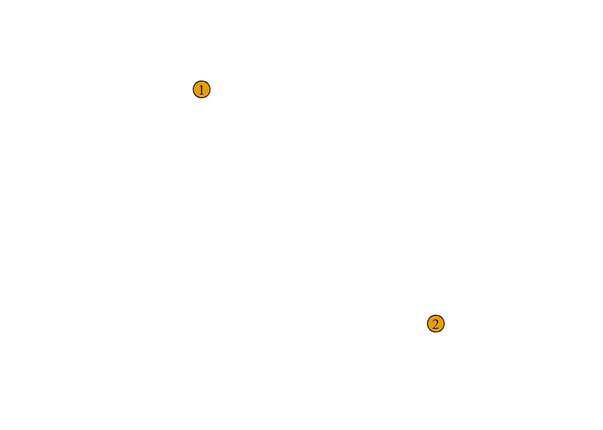

```r
kubiout <- my.kubiGraph(g,w)
kubiG <- graph.adjacency(kubiout$kubi.graph$ad)
plot(kubiG)
```

```r
kubi.unique <- kubiout$kubis$kubi
print(length(kubi.unique))
```

```
## [1] 1
```

```r
plot3d(xxx$v)
segments3d(xxx$v[c(t(xxx$edge)), ])
if(length(kubi.unique)>0){
  for(i in 1:length(kubi.unique)){
      el <- cbind(kubi.unique[[i]],c(kubi.unique[[i]][-1],kubi.unique[[i]][1]))
      segments3d(xxx$v[c(t(el)),],color=i+1,lw=4)
  }
}
```

[interactive chart not shown]

```r
ad <- get.adjacency(g)

nv <- length(V(g))
```

## 全ノードペアの測地線パスを列挙する。

```r
# Warshall-Floyd行列を作ってから、パスを取り出す
sh <- my.WarshallFloyd(g,w)
paths <- list()
for(i in 1:nv){
    paths[[i]] <- list()
}
for(i in 1:(nv-1)){
    for(j in (i+1):nv){
        paths[[i]][[j]] <- extractPath(sh,i,j)
        paths[[j]][[i]] <- paths[[i]][[j]][length(paths[[i]][[j]]):1]
    }
}
```

```
paths <- list()
for(i in 1:nv){
    paths[[i]] <- shortest_paths(g,i)[[1]]
}
#for(i in 1:(nv-1)){
    #for(j in (i+1):nv){
        #paths[[i]][[j]] <- extractPath(sh,i,j)
        #paths[[j]][[i]] <- paths[[i]][[j]][length(paths[[i]][[j]]):1]
    #}
#}
```

## 対蹠点候補ノードの列挙

対蹠点は、あるノードをルートに取り、すべてのノードに対する測地線を見出したときに、極大測地線の最先端のノードが候補となる。

したがって、ノードごとに全測地線を求め、全測地線のノードを集めたときに、１回しか登場しないノードがそれになる。それをtipノードと呼ぶことにする。

```r
tips <- list()

for(i in 1:nv){
    tmp <- unlist(paths[[i]])
    tips[[i]] <- which(table(tmp) == 1)
}
```

```
tips <- list()
paths <- list()
for(i in 1:nv){
  paths[[i]] <- shortest_paths(g,i)[[1]]
  tmp <- unlist(paths[[i]])
  tips[[i]] <- which(table(tmp) == 1)
}
```

## 大円様サイクルの列挙

あるルートノード$V$について、tipノードの２つ$U1,U2$がグラフ上、１辺で接続しているとき、$V$と$U1$、$V$と$U2$、$U1$と$U2$の３測地線を結んだサイクルが大円様サイクルの候補となる。

$V---U1$測地線と$V---U2$測地線とを構成するノードが$V$のみを共有しているとき、途中交差の無いサイクルとなるので、これを大円様サイクルとして検出する。

```r
tip.pairs <- list()
ad.half <- as.matrix(ad)
ad.half[upper.tri(ad.half)] <- 0
diag(ad.half) <- 0
for(i in 1:nv){
  add <- ad.half[tips[[i]],tips[[i]]]
  tmp <- which(add==1,arr.ind=TRUE)
  tip.pairs[[i]] <- cbind(tips[[i]][tmp[,1]],tips[[i]][tmp[,2]])
}
```

```r
cycles <- list() # サイクルを格納
cycles.half1 <- cycles.half2 <- list() # サイクルを構成する２つのパスを格納

cnt <- 1 # カウンタ
system.time(
for(i in 1:nv){
  for(j in 1:length(tip.pairs[[i]][,1])){
    path1 <- paths[[i]][[tip.pairs[[i]][j,1]]]
        path2 <- paths[[i]][[tip.pairs[[i]][j,2]]]
        path1. <- path1[c(-1,-length(path1))]
        path2. <- path2[c(-1,-length(path2))]
        tmpout <- prod(outer(path1.,path2.,"-"))
        if(tmpout != 0){
          two <- c(path1,path2[length(path2):1])
          cycles[[cnt]] <- two[-1]
            cycles.half1[[cnt]] <- path1
            cycles.half2[[cnt]] <- path2
            cnt <- cnt + 1
        }
  }
}
)
```

```
##    user  system elapsed
##    0.73    0.00    0.73
```

```
# 得られた周回路を図示
plot3d(xxx$v)
segments3d(xxx$v[c(t(xxx$edge)), ])

for(i in 1:length(cycles)){
    el <- cbind(cycles[[i]],c(cycles[[i]][-1],cycles[[i]][1]))
    segments3d(xxx$v[c(t(el)),],color=i,lw=4)
}
```

```
cycles <- list() # サイクルを格納
cycles.half1 <- cycles.half2 <- list() # サイクルを構成する２つのパスを格納

cnt <- 1 # カウンタ
system.time(
for(i in 1:nv){ # ノードごとに処理
    this.tips <- tips[[i]]
    # tipノードペアを総当り確認
    for(j in 1:(length(this.tips)-1)){
        for(k in (j+1):length(this.tips)){
          # tipノード２つがエッジで結ばれているなら、更なる処理へ進む
            if(ad[this.tips[j],this.tips[k]] == 1){
              # ２つのパスの構成ノードにルートノード以外の重複があるかどうか
                path1 <- paths[[i]][[this.tips[j]]]
                path2 <- paths[[i]][[this.tips[k]]]
                # ぐるり周回するノード順でサイクル構成ノードを並べる
                two <- c(path1,path2[length(path2):1])
                un <- unique(two)
                if(length(two) == length(un)+1){
                    cycles[[cnt]] <- two[-1]
                    cycles.half1[[cnt]] <- path1
                    cycles.half2[[cnt]] <- path2
                    cnt <- cnt + 1
                }
            }
        }
    }
}
)
```

```
cycles <- list() # サイクルを格納
cycles.half1 <- cycles.half2 <- list() # サイクルを構成する２つのパスを格納

cnt <- 1 # カウンタ
for(i in 1:nv){ # ノードごとに処理
    this.tips <- tips[[i]]
    # tipノードペアを総当り確認
    for(j in 1:(length(this.tips)-1)){
        for(k in (j+1):length(this.tips)){
          # tipノード２つがエッジで結ばれているなら、更なる処理へ進む
            if(ad[this.tips[j],this.tips[k]] == 1){
              # ２つのパスの構成ノードにルートノード以外の重複があるかどうか
                path1 <- paths[[i]][[this.tips[j]]]
                path2 <- paths[[i]][[this.tips[k]]]
                # ぐるり周回するノード順でサイクル構成ノードを並べる
                two <- c(path1,path2[length(path2):1])
                un <- unique(two)
                if(length(two) == length(un)+1){
                    cycles[[cnt]] <- two[-1]
                    cycles.half1[[cnt]] <- path1
                    cycles.half2[[cnt]] <- path2
                    cnt <- cnt + 1
                }
            }
        }
    }
}
# 周回路の長さ分布を確認
cycle.len <- sapply(cycles,length)

# 得られた周回路を図示
plot3d(xxx$v)
segments3d(xxx$v[c(t(xxx$edge)), ])

for(i in 1:length(cycles)){
    el <- cbind(cycles[[i]],c(cycles[[i]][-1],cycles[[i]][1]))
    segments3d(xxx$v[c(t(el)),],color=i,lw=4)
}
```

## くびれた周回路(首)の検出

上記で得られた周回路では、構成する半分パス上の２点間の測地線パスが周回路に含まれることは、その作成アルゴリズムから担保されている。

２つの異なるパスにある２点間の測地線もすべて周回路であるような周回路は、『ひもで縛るとそこから動かせない』ので、これを、くびれ～首周回路と呼ぶことにする。

２つの半パスをブリッジする全ノードペアについて、測地線パスが周回路にある場合のみを残す処理を回す。

```r
kubis <- list()
cnt <- 1

for(i in 1:length(cycles)){
  #print("cycle id")
  #print(i)
    len1 <- length(cycles.half1[[i]])
    len2 <- length(cycles.half2[[i]])
    br <- FALSE
    for(j in 2:(len1)){
        if(br){
            break
        }
        for(k in 2:(len2)){
            #tmp.path <- extractPath(sh,cycles.half1[[i]][j],cycles.half2[[i]][k])
          tmp.path <- paths[[cycles.half1[[i]][j]]][[cycles.half2[[i]][k]]]
            if(j==len1 & k==len2){
                br <- FALSE
                #print("last pair break")
                break
            }else{
                if(length(tmp.path)==2){
                    br <- TRUE
                    #print("len=2 break")
                    break
                }
                un <- unique(c(cycles[[i]],tmp.path))
                if(length(un) > length(cycles[[i]])){
                    br <- TRUE
                    #print("shortcut break")
                    break
                }
            }
            #print(tmp.path)
            #print(un)
        }
    }
    if(!br){
        kubis[[cnt]] <- cycles[[i]]
        cnt <- cnt + 1
    }
}

kubi.unique <- unique(lapply(kubis,sort))
```

首の数

```r
print(length(kubi.unique))
```

```
## [1] 1
```

```r
plot3d(xxx$v)
segments3d(xxx$v[c(t(xxx$edge)), ])
if(length(kubi.unique)>0){
  for(i in 1:length(kubi.unique)){
      el <- cbind(kubi.unique[[i]],c(kubi.unique[[i]][-1],kubi.unique[[i]][1]))
      segments3d(xxx$v[c(t(el)),],color=i+1,lw=4)
  }
}
```

[interactive chart not shown]